# Difference between 2019 and 2021 Outdoor Track and Field Times - Collegiate Level

Question: Is there a significant difference in the average 1500m time between 2019 and 2021? More specifically, are the 2021 College Outdoor 1500m times faster, on average, than those of 2019? For context, the 1500m is the metric equivalent of the mile. While the mile is not run at the Olympics, the 1500m is the championship standard.

- Spikes are the shoes that runners use to compete. There has been quite a bit of commentary regarding Nike's new "super spikes", namely the [Air Zoom Victory](https://www.nike.com/t/air-zoom-victory-racing-shoe-Q21pf3) and the [Dragonfly](https://www.nike.com/t/zoomx-dragoy-racing-spike-Vrr0B6). Both shoes offer superior cushioning ([Nike ZoomX](https://www.nike.com/zoomx)) foam to be exact, while the Air Zoom Victory also includes a full length carbon plate. These spikes have been said by some to even offer a synthetic advantage over traditional spikes.
- According to Nike, "...[ZoomX] is lighter, softer and more responsive than any Nike foam, designed to maximize speed by delivering greater energy return. ZoomX was derived from a foam traditionally used in aerospace innovation, applied for the first time in performance footwear in the Nike Zoom Vaporfly Elite and 4%."

The data used for this project is the simplest out there: the top 95 1500m times in the country. Both lists are taken from Division 1, combining the East and West regions. Here is a link to the [2019 Data](https://www.tfrrs.org/lists/2568.html#event13). Here is a link to the [2021 Data](https://www.tfrrs.org/lists/3191.html#event13).

The 2021 Data is taken from the date 4/26/2021. The season is not complete. I will update the data as meets complete and new results are available.

- This is not a randomized control trial. This is an observational study.
- This data collection process was quite simple.
- These results are what they are and take with them what you will.
- I do not have data on the shoes of the athletes, however from a layman's perspective, almost all of the athletes we have seen competing at an extremely high level this season have been wearing, you guessed it, the Victory or Dragonfly. In a more general sense then, we are testing whether or not the 2021 and 2019 1500m teams are significantly different.

$H_{0}: \mu_{2019} = \mu_{2021}$ : The average 1500m time in 2019 is the same as that of 2021.

$H_{1}: \mu_{2019} \neq \mu_{2021}$ : The average 1500m time in 2021 is either faster or slower than that of 2021; there is a significant difference between the two.

```python
#import all of the necessary modules
from datascience import *
import datetime
import numpy as np
from scipy import stats
from scipy.optimize import curve_fit
import matplotlib.pyplot as plot
%matplotlib inline
```

```python
#load datasets
twenty_twenty_one_outdoor_times = Table.read_table("2021 Outdoor 1500m Times 426.csv")
```

```python
twenty_nineteen_outdoor_times = Table.read_table("2019 Outdoor Times.csv")
```

```python
twenty_nineteen_outdoor_times
```

| Rank | Name | Year | School | Time | Meet | Date |
| --- | --- | --- | --- | --- | --- | --- |
| 1 | Hoare, Oliver | JR-3 | Wisconsin | 03:37.2 | Bryan Clay Invitational | 17-Apr-19 |
| 2 | Villarreal, Carlos | JR-3 | Arizona | 03:37.2 | Bryan Clay Invitational | 17-Apr-19 |
| 3 | Nuguse, Yared | SO-2 | Notre Dame | 03:38.3 | Bryan Clay Invitational | 17-Apr-19 |
| 4 | Paulson, William | SR-4 | Arizona State | 03:38.3 | Bryan Clay Invitational | 17-Apr-19 |
| 5 | Worley, Sam | SO-2 | Texas | 03:38.6 | Bryan Clay Invitational | 17-Apr-19 |
| 6 | Suliman, Waleed | SO-2 | Ole Miss | 03:38.7 | Bryan Clay Invitational | 17-Apr-19 |
| 7 | Brown, Reed | SO-2 | Oregon | 03:38.8 | Payton Jordan Invitational | 2-May-19 |
| 8 | Beamish, Geordie | JR-3 | Northern Arizona | 03:39.1 | Bryan Clay Invitational | 17-Apr-19 |
| 9 | Kusche, George | SO-2 | Nebraska | 03:39.3 | Payton Jordan Invitational | 2-May-19 |
| 10 | Grijalva, Luis | SO-2 | Northern Arizona | 03:39.5 | Bryan Clay Invitational | 17-Apr-19 |

... (85 rows omitted)

```python
#turn non-string characters into strings so that the computer can read them
string_2019_times = [str(i) for i in twenty_nineteen_outdoor_times.column("Time ")]
```

```python
string_2021_times = [str(i) for i in twenty_twenty_one_outdoor_times.column("Time")]
```

```python
#write a function to convert each time string in the dataset into a seconds-only version, which makes it easier to graph
def split_minutes_and_seconds(time_str):
    """Get Seconds from time."""
    split_list = (time_str.split(":"))
    milliseconds = (split_list[1].split("."))
    int_milliseconds = [int(i) for i in milliseconds]
    return int(split_list[0]) * 60 + int_milliseconds[0] + int_milliseconds[1] / 10

split_minutes_and_seconds("03:39.7")
```

```
219.7
```

```python
clean_2019_times = [split_minutes_and_seconds(i) for i in string_2019_times]
```

```python
clean_2021_times = [split_minutes_and_seconds(i) for i in string_2021_times]
```

```python
len(clean_2021_times)
```

```
100
```

```python
#deleting the last five rows of the 2021 dataset so that the length of each dataset is the same
del clean_2021_times[95:100]
```

```python
len(clean_2021_times)
```

```
95
```

```python
len(clean_2019_times)
```

```
95
```

```python
#creating the final table
final_table = Table().with_columns("Rank", np.arange(1, 96, 1))
```

```python
final_table = final_table.with_column("2019 Outdoor 1500m Times", clean_2019_times)
```

```python
final_table = final_table.with_column("2021 Outdoor 1500m Times", clean_2021_times)
```

```python
final_table
```

| Rank | 2019 Outdoor 1500m Times | 2021 Outdoor 1500m Times |
| --- | --- | --- |
| 1 | 217.2 | 216 |
| 2 | 217.2 | 216.5 |
| 3 | 218.3 | 217 |
| 4 | 218.3 | 217.2 |
| 5 | 218.6 | 217.2 |
| 6 | 218.7 | 217.8 |
| 7 | 218.8 | 217.8 |
| 8 | 219.1 | 218.1 |
| 9 | 219.3 | 218.3 |
| 10 | 219.5 | 218.6 |

... (85 rows omitted)

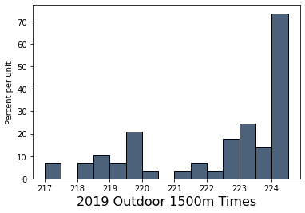

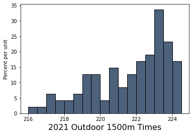

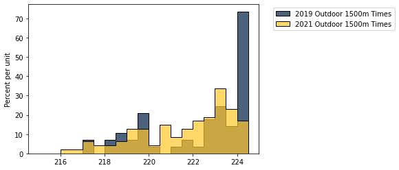

```python
final_table.hist(1, bins = np.arange(217, 225, 0.5))
final_table.hist(2, bins = np.arange(216, 225, 0.5))
final_table.hist(1,2, bins = np.arange(215, 225, 0.5))
```

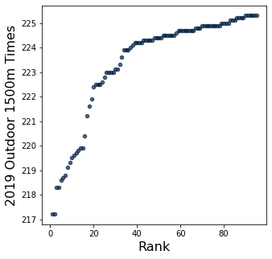

```python
#code to create a scatter of the overall rank vs. 2019 outdoor 1500m time
final_table.scatter("Rank","2019 Outdoor 1500m Times")
```

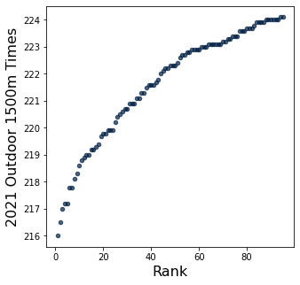

```python
#code to create a scatter of the overall rank vs. 2021 outdoor 1500m time
final_table.scatter("Rank","2021 Outdoor 1500m Times")
```

Upon inspection of both of these datasets, I am actually tempted to use exponential regression to model the data. I'll do that another day though, because that is not the focus of this current project.

```python
nineteen_avg = np.mean(final_table.column("2019 Outdoor 1500m Times"))
twentyone_avg = np.mean(final_table.column("2021 Outdoor 1500m Times"))
nineteen_sd = np.std(final_table.column("2019 Outdoor 1500m Times"))
twentyone_sd = np.std(final_table.column("2021 Outdoor 1500m Times"))
```

```python
print(nineteen_avg, nineteen_sd)
```

```
223.37578947368414 2.1763182714935256
```

```python
print(twentyone_avg, twentyone_sd)
```

```
221.62105263157895 2.0807839988479087
```

Now it's time to talk about the two distributions. For 2019, the average, $\bar{X}_{2019}$, was $03:43.37$, while the average for 2021 was $03:41.62$. The standard deviation for 2019, $\sigma_{2019}$, was 2.176, while that of 2021, $\sigma_{2021}$, was 2.0807.

You can tell from these two histograms that there is obvious left skewness, and that they are not normally distributed. I'm going to use the fact that I can take the sample mean of a sample of sufficient size, and that sample will be approximately normal. Under those rules, I can use the central limit theorem.

What follows is that the distribution of the difference of sample means is distributed, $\bar{X}_{2019} - \bar{X}_{2021}$, and the difference in standard deviation can be computed as $\sqrt{\frac{2.1763182714935256^2}{95} + \frac{2.0807839988479087^2}{95}}$

```python
import math
```

```python
nineteen_variance = (nineteen_sd**2 / 95)
twentyone_variance = (twentyone_sd**2 / 95)
difference_sd = math.sqrt(nineteen_variance + twentyone_variance)
difference_sd
```

```
0.3089204167435882
```

```python
difference_mean = (nineteen_avg - twentyone_avg)
difference_mean
```

```
1.7547368421051885
```

A 95% confidence interval for the true difference between the two sample means would be as follows:

To select our z-score, we look at the normal curve. For a $95\%$ confidence interval, we look at the data in the middle $95\%$. This means that we need to find $\Phi^{-1}(0.975)$ for the positive upper value. Here, $\Phi^{-1}$ indicates that we are using the inverse of the normal CDF.

The formula to find the upper and lower bounds of our confidence interval is:

CI = $\bar{X} \pm z * SD(\bar{X})$

```python
z = stats.norm.ppf(0.975)
ci_lower = difference_mean - (z * difference_sd)
ci_upper = difference_mean + (z * difference_sd)
ci_lower, ci_upper
```

```
(1.1492639511986513, 2.3602097330117258)
```

- It must be noted that this is a 95% confidence interval. We must perform a hypothesis test to come to an outright conclusion, of whether the data favor the null or alternative hypotheses. Once the season is over and the data is final, I will complete the hypothesis test.

Now let's have some fun with the data. I mentioned before that I thought that there was some clustering in relation to the range 3:38 to 3:43. Well, let's see the count of each between both data sets.

```python
final_table.where("2019 Outdoor 1500m Times", are.between_or_equal_to(218,223)).num_rows
```

```
27
```

```python
final_table.where("2021 Outdoor 1500m Times", are.between_or_equal_to(218,223)).num_rows
```

```
56
```

Wow! There are almost double the amount of times between 3:38 and 3:43 in comparison to those of 2019. 56 vs. 27. That's a 107% increase in concentration of 1500m times in that range from 2019.

```python
nineteen_percentiles = [percentile(i, final_table.column(1)) for i in range(0, 110, 10)]
twentyone_percentiles = [percentile(i, final_table.column(2)) for i in range(0, 110, 10)]
x_axis_values = np.arange(0, 101, 10)
```

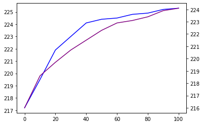

```python
figure, axis_1 = plot.subplots()
axis_1.plot(x_axis_values, nineteen_percentiles, color = "blue")
axis_2 = axis_1.twinx()
axis_2.plot(x_axis_values, twentyone_percentiles, color = "purple")
```

```python
#export the cleaned data to my computer so I can easily visualize within R and Plotly
final_table.to_csv("2019 and 2021 Outdoor 1500m Data.csv")
```

```python
#creating an x-axis for the normal curve
x_values = np.arange(0, 500, 0.01)
```

```python
#using the equation of the gaussian function to model a theoretical distribution of the mean for each year
y_values = (1 / math.sqrt(2*math.pi))**(np.e**(-0.5*((x_values - nineteen_avg) / (nineteen_sd / math.sqrt(95))))**2)
```

```python
y_values_2 = (1 / math.sqrt(2*math.pi))**(np.e**(-0.5*((x_values - twentyone_avg) / (twentyone_sd / math.sqrt(95))))**2)
```

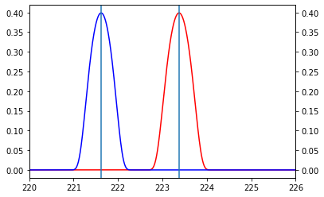

```python
#using the guassian equation to draw two normal distributions of the data
figure_2, axis_2= plot.subplots()
axis_2.plot(x_values, y_values, color = "red", label = "2019")
axis_3 = axis_2.twinx()
axis_3.plot(x_values, y_values_2, color = "blue")
plot.xlim(220, 226)
plot.axvline(x=nineteen_avg)
plot.axvline(x=twentyone_avg)
```